# Final Project

Shane Taylor shanemt2@illinois.edu; Zhouning Ma zm11@illinois.edu; Kevin Mackie kevindm2@illinois.edu

7/28/2019

# Group members

- Shane Taylor shanemt2@illinois.edu
- Zhouning Ma zm11@illinois.edu
- Kevin Mackie kevindm2@illinois.edu

# Library

```r
library(GGally)
library(faraway)
```

```r
library(leaps)
library(corpcor)
library(corrplot)
library(ggcorrplot)
library(knitr)
library(kableExtra)
library(caret)
library(outliers)
library(MASS)
library(faraway)
library(ggplot2)
library(ggthemes)
library(lmtest)
# If you failed to run the Markdown, you may run the following install.packages again for the dependencies
#install.packages("corrplot")
#install.packages("kableExtra")
#install.packages('caret', dependencies = TRUE)
#install.packages('e1071', dependencies=TRUE)
```

#Public method

```r
is_debug = FALSE
missing = "missing"
response  = c("SalePrice")
ptm = proc.time()



calc_loocv_rmse = function(model) {
  sqrt(mean((resid(model) / (1 - hatvalues(model))) ^ 2))
}

mape = function(actual, pred){
  mean(abs((actual - pred) / actual)) * 100
}

convert_factor_to_numeric = function(variable){
  result = as.numeric(variable)
  result[which(is.na(result))] = 0
  result
}

factor_preprocess = function(variable){
  level = unique(variable)
  numberoflevel = length(level)

  factor(variable, levels = level, labels = seq(1, numberoflevel))
}

start_log = function(){
  if (is_debug){
     ptm = proc.time()
  }
}

end_log = function(){
    if (is_debug){
       print(proc.time() - ptm)
    }
}

validate_data_structure = function(dataset1, dataset2){
  validate_result = TRUE
  for (i in which(sapply(dataset2, is.factor))) {
     level1 = unique(dataset1[, i])
     level2 = unique(dataset2[, i])


     if (length(setdiff(level1, level2)) > 0){
         print(level1)
         print(level2)
         validate_result = FALSE
     }
     if (length(setdiff(level2, level1)) > 0){
         print(level2)
         print(level1)
         validate_result = FALSE
     }
  }
  validate_result
}


remove_no_existing_factors = function(test_dataset, base_dataset){
  result_dataset = test_dataset
  base_names = names(base_dataset)
  for (i in which(sapply(test_dataset, is.factor))) {
     test_column_name = names(test_dataset)[i]
     if (test_column_name %in%  base_names){
         train_levels = unique(base_dataset[, test_column_name])
         result_dataset = subset(result_dataset, (result_dataset[,test_column_name] %in% train_levels))
     }
  }
  result_dataset
}
```

```r
remove_leverage_Observations = function(model, data){
     data[-which(hatvalues(model) > 2 * mean(hatvalues(model))), ]
}

remove_Outliers_Observations = function(model, data){
     data[-which(abs(rstandard(model)) > 2), ]
}

remove_Influence_Observations = function(model, data){
     data[-which(cooks.distance(model) > 4 / length(cooks.distance(model))), ]
}

remove_unusual_observations = function(model, dataset){
    dataset = remove_leverage_Observations(model, dataset)
    dataset = remove_Outliers_Observations(model, dataset)
    dataset = remove_Influence_Observations(model, dataset)
    dataset = drop_only_one_level_factor(dataset)
    dataset
}



build_additive_model = function(dataset){
    model = lm(SalePrice ~ ., data = dataset)
    model
}
```

```r
preprocess = function(dataset){
  datasetv1 = dataset
  for (i in which(sapply(dataset, is.numeric))) {
      datasetv1[is.na(dataset[, i]), i] = mean(dataset[, i],  na.rm = TRUE)
  }


  # factor preprocess
  datasetv2 = datasetv1
  for (i in which(sapply(datasetv1, is.character))) {
      datasetv2[is.na(datasetv1[, i]), i] = missing
      datasetv2[, i] = as.factor(datasetv2[, i])
  }

  datasetv2
}


drop_only_one_level_factor = function(dataset){
  datasetv1 = dataset
  droplist = c()
  for (i in which(sapply(dataset, is.factor))) {
      level = unique(dataset[, i])
      if ((length(level) <= 1) | ((length(level) == 2) & (missing %in% level))){
          droplist = c(droplist, i)
      }
  }

  for (i in which(sapply(datasetv1, is.numeric))) {
      level = unique(datasetv1[, i])
      if (length(level) <= 1){
          droplist = c(droplist, i)
      }
  }
  if (length(droplist) > 0){
      datasetv1 = datasetv1[ , -droplist]
  }
  datasetv1
}
```

# Introduction

The data, which was found on Kaggle, is a publicly available data set on housing prices in the city of Ames, Iowa that was curated by Dean De Cock of Truman state university.

- https://www.kaggle.com/c/house-prices-advanced-regression-techniques/overview
- http://jse.amstat.org/v19n3/decock.pdf

It consists of 1460 observations with one numerical response (house price) and 80 predictors. The predictors are a relatively even mix of numerical and categorical variables.

Here’s a brief version of what you’ll find in the data description file.

- SalePrice - the property’s sale price in dollars. This is the target variable that you’re trying to predict.
- MSSubClass: The building class - # what do 20, 60, 70, etc…. represent?
- MSZoning: The general zoning classification : factors = { C (all), FV, RH, RL, RM }
- LotFrontage: Linear feet of street connected to property
- LotArea: Lot size in square feet
- Street: Type of road access : factors = { Grvl, Pave }
- Alley: Type of alley access : factors = { Grvl, Pave }
- LotShape: General shape of property : factors = { IR1, IR2, IR3, Reg }
- LandContour: Flatness of the property : factors = { Bnk, HLS, Low, Lvl }
- Utilities: Type of utilities available : factors = { AllPub, NoSeWa }
- LotConfig: Lot configuration : factors = { Corner, CulDSac, FR2, FR3, Inside }
- LandSlope: Slope of property : factors = { Gtl, Mod, Sev }
- Neighborhood: Physical locations within Ames city limits : factors = { Blmngtn, Blueste, …}
- Condition1: Proximity to main road or railroad : factors = { Artery, Feedr, Norm, PosA, …}
- Condition2: Proximity to main road or railroad (if a second is present) : factors = { Artery, Feedr, … }
- BldgType: Type of dwelling : factors = { 1Fam, 2fmCon, Duplex, Twnhs, TwnhsE }
- HouseStyle: Style of dwelling : factors = { 1.5Fin, 1.5Unf, 1Story, 2.5Fin, 2.5Unf, 2Story, SFoyer, SLvl }
- OverallQual: Overall material and finish quality
- OverallCond: Overall condition rating
- YearBuilt: Original construction date
- YearRemodAdd: Remodel date
- RoofStyle: Type of roof : factors = { Flat, Gable, Gambrel, Hip, Mansard, Shed }
- RoofMatl: Roof material : factors = { ClyTile, CompShg, Membran, Metal, Roll, Tar&Grv, WdShake, WdShngl }
- Exterior1st: Exterior covering on house : factors = { AsbShng, AsphShn, BrkComm, BrkFace, CBlock, … }
- Exterior2nd: Exterior covering on house (if more than one material) : factors = { AsbShng, AsphShn, … }
- MasVnrType: Masonry veneer type : factors = { BrkCmn, BrkFace, None, Stone }
- MasVnrArea: Masonry veneer area in square feet
- ExterQual: Exterior material quality : factors = { Ex, Fa, Gd, TA }
- ExterCond: Present condition of the material on the exterior : factors = { Ex, Fa, Gd, Po, TA }
- Foundation: Type of foundation : factors = { BrkTil, CBlock, PConc, Slab, Stone, Wood }
- BsmtQual: Height of the basement : factors = { Ex, Fa, Gd, TA }
- BsmtCond: General condition of the basement : factors = { Fa, Gd, Po, TA }
- BsmtExposure: Walkout or garden level basement walls : factors = { Av, Gd, Mn, No }
- BsmtFinType1: Quality of basement finished area : factors = { ALQ, BLQ, GLQ, LwQ, Rec, Unf }
- BsmtFinSF1: Type 1 finished square feet
- BsmtFinType2: Quality of second finished area (if present) : factors = { ALQ, BLQ, GLQ, LwQ, Rec, Unf }
- BsmtFinSF2: Type 2 finished square feet
- BsmtUnfSF: Unfinished square feet of basement area
- TotalBsmtSF: Total square feet of basement area
- Heating: Type of heating : factors = { Floor, GasA, GasW, Grav, OthW, Wall }
- HeatingQC: Heating quality and condition : factors = { Ex, Fa, Gd, Po, TA }
- CentralAir: Central air conditioning : factors = { N, Y }
- Electrical: Electrical system : factors = { FuseA, FuseF, FuseP, Mix, SBrkr }
- 1stFlrSF: First Floor square feet
- 2ndFlrSF: Second floor square feet
- LowQualFinSF: Low quality finished square feet (all floors)
- GrLivArea: Above grade (ground) living area square feet
- BsmtFullBath: Basement full bathrooms
- BsmtHalfBath: Basement half bathrooms
- FullBath: Full bathrooms above grade
- HalfBath: Half baths above grade
- Bedroom: Number of bedrooms above basement level
- Kitchen: Number of kitchens
- KitchenQual: Kitchen quality : factors = { Ex, Fa, Gd, TA }
- TotRmsAbvGrd: Total rooms above grade (does not include bathrooms)
- Functional: Home functionality rating : factors = { Maj1, Maj2, Min1, Min2, Mod, Sev, Typ }
- Fireplaces: Number of fireplaces
- FireplaceQu: Fireplace quality : factors = { Ex, Fa, Gd, Po, TA }
- GarageType: Garage location : factors = { 2Types, Attchd, Basment, BuiltIn, CarPort, Detchd }
- GarageYrBlt: Year garage was built
- GarageFinish: Interior finish of the garage : factors = { Fin, RFn, Unf }
- GarageCars: Size of garage in car capacity
- GarageArea: Size of garage in square feet
- GarageQual: Garage quality : factors = { Ex, Fa, Gd, Po, TA }
- GarageCond: Garage condition : factors = { Ex, Fa, Gd, Po, TA }
- PavedDrive: Paved driveway : factors = { N, P, Y }
- WoodDeckSF: Wood deck area in square feet
- OpenPorchSF: Open porch area in square feet
- EnclosedPorch: Enclosed porch area in square feet
- 3SsnPorch: Three season porch area in square feet
- ScreenPorch: Screen porch area in square feet
- PoolArea: Pool area in square feet
- PoolQC: Pool quality : factors = { Ex, Fa, Gd }
- Fence: Fence quality : factors = { GdPrv, GdWo, MnPrv, MnWw }
- MiscFeature: Miscellaneous feature not covered in other categories : factors = { Gar2, Othr, Shed, TenC }
- MiscVal: $Value of miscellaneous feature
- MoSold: Month Sold
- YrSold: Year Sold
- SaleType: Type of sale : factors = { COD, Con, ConLD, ConLI, ConLw, CWD, New, Oth, WD }
- SaleCondition: Condition of sale : factors = { Abnorml, AdjLand, Alloca, Family, Normal, Partial }

For this project our goal will be to attempt to find a “good model” (see below) using a variety of methods that both performs well and is good for explanatory purposes.

A “good model” should:

# Methods

## Exploratory Data Analysis

> Read the train.csv file, and run the preprocess, what preprocess doing is: - If the variable is numeric and is na, then use mean to replace; - Replace the na factor value to “missing”, this will make model process easier;

```r
train = read.csv("train.csv", stringsAsFactors=FALSE)[, -1]
house_prices_train = preprocess(train)
```

> We will run collinearity Test

##Correlation tests

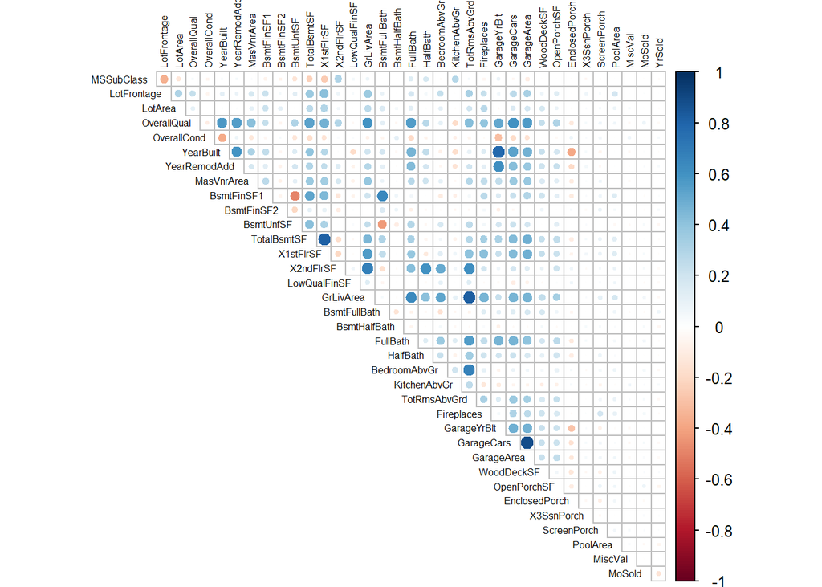

```r
correlation_tests = function(data){
   drops <- c("SalePrice")
   X = data[ , !(names(data) %in% drops)]
   round(cor(X, use = "everything"), 4)
}

correlation_plot = function(corr_data){
   corrplot(corr_data, type = "upper", tl.pos = "td",
         method = "circle", tl.cex = 0.5, tl.col = 'black',
         diag = FALSE)
}

correlation_table = function(corr_data){
   kable(corr_data, "html") %>%
     kable_styling(bootstrap_options = "striped", font_size = 9) %>%
     scroll_box(width = "100%", height = "500px")
}

correlation_list = function(corr_data){
    corr_data[which(corr_data > 0.8)]
}


X_numeric = house_prices_train[sapply(house_prices_train, is.numeric)]
correlation_test_result = correlation_tests(X_numeric)
correlation_plot(correlation_test_result)
```

```r
correlation_table(correlation_test_result)
```

|  | MSSubClass | LotFrontage | LotArea | OverallQual | OverallCond | YearBuilt | YearRemodAdd | MasVnrArea | BsmtFinSF1 | BsmtFinSF2 | BsmtUnfSF | TotalBsmtSF | X1stFlrSF | X2ndFlrSF | LowQualFinSF | GrLivArea | BsmtFullBath | BsmtHalfBath | FullBath | HalfBath | BedroomAbvGr | KitchenAbvGr | TotRmsAbvGrd | Fireplaces | GarageYrBlt | GarageCars | GarageArea | WoodDeckSF | OpenPorchSF | … |
| --- | --- | --- | --- | --- | --- | --- | --- | --- | --- | --- | --- | --- | --- | --- | --- | --- | --- | --- | --- | --- | --- | --- | --- | --- | --- | --- | --- | --- | --- | --- |
| MSSubClass | 1.0000 | -0.3571 | -0.1398 | 0.0326 | -0.0593 | 0.0279 | 0.0406 | 0.0229 | -0.0698 | -0.0656 | -0.1408 | -0.2385 | -0.2518 | 0.3079 | 0.0465 | 0.0749 | 0.0035 | -0.0023 | 0.1316 | 0.1774 | -0.0234 | 0.2817 | 0.0404 | -0.0456 | 0.0802 | -0.0401 | -0.0987 | -0.0126 | -0.0061 | … |
| LotFrontage | -0.3571 | 1.0000 | 0.3068 | 0.2342 | -0.0528 | 0.1176 | 0.0827 | 0.1793 | 0.2158 | 0.0433 | 0.1222 | 0.3634 | 0.4143 | 0.0725 | 0.0368 | 0.3684 | 0.0915 | -0.0064 | 0.1804 | 0.0483 | 0.2370 | -0.0058 | 0.3201 | 0.2358 | 0.0643 | 0.2697 | 0.3237 | 0.0771 | 0.1375 | … |
| LotArea | -0.1398 | 0.3068 | 1.0000 | 0.1058 | -0.0056 | 0.0142 | 0.0138 | 0.1040 | 0.2141 | 0.1112 | -0.0026 | 0.2608 | 0.2995 | 0.0510 | 0.0048 | 0.2631 | 0.1582 | 0.0480 | 0.1260 | 0.0143 | 0.1197 | -0.0178 | 0.1900 | 0.2714 | -0.0248 | 0.1549 | 0.1804 | 0.1717 | 0.0848 | … |
| OverallQual | 0.0326 | 0.2342 | 0.1058 | 1.0000 | -0.0919 | 0.5723 | 0.5507 | 0.4102 | 0.2397 | -0.0591 | 0.3082 | 0.5378 | 0.4762 | 0.2955 | -0.0304 | 0.5930 | 0.1111 | -0.0402 | 0.5506 | 0.2735 | 0.1017 | -0.1839 | 0.4275 | 0.3968 | 0.5180 | 0.6007 | 0.5620 | 0.2389 | 0.3088 | … |
| OverallCond | -0.0593 | -0.0528 | -0.0056 | -0.0919 | 1.0000 | -0.3760 | 0.0737 | -0.1278 | -0.0462 | 0.0402 | -0.1368 | -0.1711 | -0.1442 | 0.0289 | 0.0255 | -0.0797 | -0.0549 | 0.1178 | -0.1941 | -0.0608 | 0.0130 | -0.0870 | -0.0576 | -0.0238 | -0.3062 | -0.1858 | -0.1515 | -0.0033 | -0.0326 | … |
| YearBuilt | 0.0279 | 0.1176 | 0.0142 | 0.5723 | -0.3760 | 1.0000 | 0.5929 | 0.3147 | 0.2495 | -0.0491 | 0.1490 | 0.3915 | 0.2820 | 0.0103 | -0.1838 | 0.1990 | 0.1876 | -0.0382 | 0.4683 | 0.2427 | -0.0707 | -0.1748 | 0.0956 | 0.1477 | 0.7806 | 0.5379 | 0.4790 | 0.2249 | 0.1887 | … |
| YearRemodAdd | 0.0406 | 0.0827 | 0.0138 | 0.5507 | 0.0737 | 0.5929 | 1.0000 | 0.1792 | 0.1285 | -0.0678 | 0.1811 | 0.2911 | 0.2404 | 0.1400 | -0.0624 | 0.2874 | 0.1195 | -0.0123 | 0.4390 | 0.1833 | -0.0406 | -0.1496 | 0.1917 | 0.1126 | 0.6181 | 0.4206 | 0.3716 | 0.2057 | 0.2263 | … |
| MasVnrArea | 0.0229 | 0.1793 | 0.1040 | 0.4102 | -0.1278 | 0.3147 | 0.1792 | 1.0000 | 0.2636 | -0.0723 | 0.1142 | 0.3625 | 0.3422 | 0.1740 | -0.0691 | 0.3899 | 0.0851 | 0.0267 | 0.2757 | 0.2008 | 0.1024 | -0.0374 | 0.2800 | 0.2479 | 0.2494 | 0.3638 | 0.3726 | 0.1593 | 0.1250 | … |
| BsmtFinSF1 | -0.0698 | 0.2158 | 0.2141 | 0.2397 | -0.0462 | 0.2495 | 0.1285 | 0.2636 | 1.0000 | -0.0501 | -0.4953 | 0.5224 | 0.4459 | -0.1371 | -0.0645 | 0.2082 | 0.6492 | 0.0674 | 0.0585 | 0.0043 | -0.1074 | -0.0810 | 0.0443 | 0.2600 | 0.1503 | 0.2241 | 0.2970 | 0.2043 | 0.1118 | … |
| BsmtFinSF2 | -0.0656 | 0.0433 | 0.1112 | -0.0591 | 0.0402 | -0.0491 | -0.0678 | -0.0723 | -0.0501 | 1.0000 | -0.2093 | 0.1048 | 0.0971 | -0.0993 | 0.0148 | -0.0096 | 0.1587 | 0.0709 | -0.0764 | -0.0321 | -0.0157 | -0.0408 | -0.0352 | 0.0469 | -0.0871 | -0.0383 | -0.0182 | 0.0679 | 0.0031 | … |
| BsmtUnfSF | -0.1408 | 0.1222 | -0.0026 | 0.3082 | -0.1368 | 0.1490 | 0.1811 | 0.1142 | -0.4953 | -0.2093 | 1.0000 | 0.4154 | 0.3180 | 0.0045 | 0.0282 | 0.2403 | -0.4229 | -0.0958 | 0.2889 | -0.0411 | 0.1666 | 0.0301 | 0.2506 | 0.0516 | 0.1861 | 0.2142 | 0.1833 | -0.0053 | 0.1290 | … |
| TotalBsmtSF | -0.2385 | 0.3634 | 0.2608 | 0.5378 | -0.1711 | 0.3915 | 0.2911 | 0.3625 | 0.5224 | 0.1048 | 0.4154 | 1.0000 | 0.8195 | -0.1745 | -0.0332 | 0.4549 | 0.3074 | -0.0003 | 0.3237 | -0.0488 | 0.0504 | -0.0689 | 0.2856 | 0.3395 | 0.3117 | 0.4346 | 0.4867 | 0.2320 | 0.2473 | … |
| X1stFlrSF | -0.2518 | 0.4143 | 0.2995 | 0.4762 | -0.1442 | 0.2820 | 0.2404 | 0.3422 | 0.4459 | 0.0971 | 0.3180 | 0.8195 | 1.0000 | -0.2026 | -0.0142 | 0.5660 | 0.2447 | 0.0020 | 0.3806 | -0.1199 | 0.1274 | 0.0681 | 0.4095 | 0.4105 | 0.2271 | 0.4393 | 0.4898 | 0.2355 | 0.2117 | … |
| X2ndFlrSF | 0.3079 | 0.0725 | 0.0510 | 0.2955 | 0.0289 | 0.0103 | 0.1400 | 0.1740 | -0.1371 | -0.0993 | 0.0045 | -0.1745 | -0.2026 | 1.0000 | 0.0634 | 0.6875 | -0.1695 | -0.0239 | 0.4214 | 0.6097 | 0.5029 | 0.0593 | 0.6164 | 0.1946 | 0.0693 | 0.1839 | 0.1383 | 0.0922 | 0.2080 | … |
| LowQualFinSF | 0.0465 | 0.0368 | 0.0048 | -0.0304 | 0.0255 | -0.1838 | -0.0624 | -0.0691 | -0.0645 | 0.0148 | 0.0282 | -0.0332 | -0.0142 | 0.0634 | 1.0000 | 0.1347 | -0.0471 | -0.0058 | -0.0007 | -0.0271 | 0.1056 | 0.0075 | 0.1312 | -0.0213 | -0.0292 | -0.0945 | -0.0676 | -0.0254 | 0.0183 | … |
| GrLivArea | 0.0749 | 0.3684 | 0.2631 | 0.5930 | -0.0797 | 0.1990 | 0.2874 | 0.3899 | 0.2082 | -0.0096 | 0.2403 | 0.4549 | 0.5660 | 0.6875 | 0.1347 | 1.0000 | 0.0348 | -0.0189 | 0.6300 | 0.4158 | 0.5213 | 0.1001 | 0.8255 | 0.4617 | 0.2220 | 0.4672 | 0.4690 | 0.2474 | 0.3302 | … |
| BsmtFullBath | 0.0035 | 0.0915 | 0.1582 | 0.1111 | -0.0549 | 0.1876 | 0.1195 | 0.0851 | 0.6492 | 0.1587 | -0.4229 | 0.3074 | 0.2447 | -0.1695 | -0.0471 | 0.0348 | 1.0000 | -0.1479 | -0.0645 | -0.0309 | -0.1507 | -0.0415 | -0.0533 | 0.1379 | 0.1199 | 0.1319 | 0.1792 | 0.1753 | 0.0673 | … |
| BsmtHalfBath | -0.0023 | -0.0064 | 0.0480 | -0.0402 | 0.1178 | -0.0382 | -0.0123 | 0.0267 | 0.0674 | 0.0709 | -0.0958 | -0.0003 | 0.0020 | -0.0239 | -0.0058 | -0.0189 | -0.1479 | 1.0000 | -0.0545 | -0.0123 | 0.0465 | -0.0379 | -0.0238 | 0.0290 | -0.0751 | -0.0209 | -0.0245 | 0.0402 | -0.0253 | … |
| FullBath | 0.1316 | 0.1804 | 0.1260 | 0.5506 | -0.1941 | 0.4683 | 0.4390 | 0.2757 | 0.0585 | -0.0764 | 0.2889 | 0.3237 | 0.3806 | 0.4214 | -0.0007 | 0.6300 | -0.0645 | -0.0545 | 1.0000 | 0.1364 | 0.3633 | 0.1331 | 0.5548 | 0.2437 | 0.4685 | 0.4697 | 0.4057 | 0.1877 | 0.2600 | … |
| HalfBath | 0.1774 | 0.0483 | 0.0143 | 0.2735 | -0.0608 | 0.2427 | 0.1833 | 0.2008 | 0.0043 | -0.0321 | -0.0411 | -0.0488 | -0.1199 | 0.6097 | -0.0271 | 0.4158 | -0.0309 | -0.0123 | 0.1364 | 1.0000 | 0.2267 | -0.0683 | 0.3434 | 0.2036 | 0.1911 | 0.2192 | 0.1635 | 0.1081 | 0.1997 | … |
| BedroomAbvGr | -0.0234 | 0.2370 | 0.1197 | 0.1017 | 0.0130 | -0.0707 | -0.0406 | 0.1024 | -0.1074 | -0.0157 | 0.1666 | 0.0504 | 0.1274 | 0.5029 | 0.1056 | 0.5213 | -0.1507 | 0.0465 | 0.3633 | 0.2267 | 1.0000 | 0.1986 | 0.6766 | 0.1076 | -0.0603 | 0.0861 | 0.0653 | 0.0469 | 0.0938 | … |
| KitchenAbvGr | 0.2817 | -0.0058 | -0.0178 | -0.1839 | -0.0870 | -0.1748 | -0.1496 | -0.0374 | -0.0810 | -0.0408 | 0.0301 | -0.0689 | 0.0681 | 0.0593 | 0.0075 | 0.1001 | -0.0415 | -0.0379 | 0.1331 | -0.0683 | 0.1986 | 1.0000 | 0.2560 | -0.1239 | -0.1076 | -0.0506 | -0.0644 | -0.0901 | -0.0701 | … |
| TotRmsAbvGrd | 0.0404 | 0.3201 | 0.1900 | 0.4275 | -0.0576 | 0.0956 | 0.1917 | 0.2800 | 0.0443 | -0.0352 | 0.2506 | 0.2856 | 0.4095 | 0.6164 | 0.1312 | 0.8255 | -0.0533 | -0.0238 | 0.5548 | 0.3434 | 0.6766 | 0.2560 | 1.0000 | 0.3261 | 0.1408 | 0.3623 | 0.3378 | 0.1660 | 0.2342 | … |
| Fireplaces | -0.0456 | 0.2358 | 0.2714 | 0.3968 | -0.0238 | 0.1477 | 0.1126 | 0.2479 | 0.2600 | 0.0469 | 0.0516 | 0.3395 | 0.4105 | 0.1946 | -0.0213 | 0.4617 | 0.1379 | 0.0290 | 0.2437 | 0.2036 | 0.1076 | -0.1239 | 0.3261 | 1.0000 | 0.0456 | 0.3008 | 0.2691 | 0.2000 | 0.1694 | … |
| GarageYrBlt | 0.0802 | 0.0643 | -0.0248 | 0.5180 | -0.3062 | 0.7806 | 0.6181 | 0.2494 | 0.1503 | -0.0871 | 0.1861 | 0.3117 | 0.2271 | 0.0693 | -0.0292 | 0.2220 | 0.1199 | -0.0751 | 0.4685 | 0.1911 | -0.0603 | -0.1076 | 0.1408 | 0.0456 | 1.0000 | 0.4825 | 0.4765 | 0.2206 | 0.2185 | … |
| GarageCars | -0.0401 | 0.2697 | 0.1549 | 0.6007 | -0.1858 | 0.5379 | 0.4206 | 0.3638 | 0.2241 | -0.0383 | 0.2142 | 0.4346 | 0.4393 | 0.1839 | -0.0945 | 0.4672 | 0.1319 | -0.0209 | 0.4697 | 0.2192 | 0.0861 | -0.0506 | 0.3623 | 0.3008 | 0.4825 | 1.0000 | 0.8825 | 0.2263 | 0.2136 | … |
| GarageArea | -0.0987 | 0.3237 | 0.1804 | 0.5620 | -0.1515 | 0.4790 | 0.3716 | 0.3726 | 0.2970 | -0.0182 | 0.1833 | 0.4867 | 0.4898 | 0.1383 | -0.0676 | 0.4690 | 0.1792 | -0.0245 | 0.4057 | 0.1635 | 0.0653 | -0.0644 | 0.3378 | 0.2691 | 0.4765 | 0.8825 | 1.0000 | 0.2247 | 0.2414 | … |
| WoodDeckSF | -0.0126 | 0.0771 | 0.1717 | 0.2389 | -0.0033 | 0.2249 | 0.2057 | 0.1593 | 0.2043 | 0.0679 | -0.0053 | 0.2320 | 0.2355 | 0.0922 | -0.0254 | 0.2474 | 0.1753 | 0.0402 | 0.1877 | 0.1081 | 0.0469 | -0.0901 | 0.1660 | 0.2000 | 0.2206 | 0.2263 | 0.2247 | 1.0000 | 0.0587 | … |
| OpenPorchSF | -0.0061 | 0.1375 | 0.0848 | 0.3088 | -0.0326 | 0.1887 | 0.2263 | 0.1250 | 0.1118 | 0.0031 | 0.1290 | 0.2473 | 0.2117 | 0.2080 | 0.0183 | 0.3302 | 0.0673 | -0.0253 | 0.2600 | 0.1997 | 0.0938 | -0.0701 | 0.2342 | 0.1694 | 0.2185 | 0.2136 | 0.2414 | 0.0587 | 1.0000 | … |
| EnclosedPorch | -0.0120 | 0.0098 | -0.0183 | -0.1139 | 0.0704 | -0.3873 | -0.1939 | -0.1098 | -0.1023 | 0.0365 | -0.0025 | -0.0955 | -0.0653 | 0.0620 | 0.0611 | 0.0091 | -0.0499 | -0.0086 | -0.1151 | -0.0953 | 0.0416 | 0.0373 | 0.0042 | -0.0248 | -0.2859 | -0.1514 | -0.1218 | -0.1260 | -0.0931 | … |
| X3SsnPorch | -0.0438 | 0.0623 | 0.0204 | 0.0304 | 0.0255 | 0.0314 | 0.0453 | 0.0188 | 0.0265 | -0.0300 | 0.0208 | 0.0374 | 0.0561 | -0.0244 | -0.0043 | 0.0206 | -0.0001 | 0.0351 | 0.0354 | -0.0050 | -0.0245 | -0.0246 | -0.0067 | 0.0113 | 0.0235 | 0.0358 | 0.0351 | -0.0328 | -0.0058 | … |
| ScreenPorch | -0.0260 | 0.0377 | 0.0432 | 0.0649 | 0.0548 | -0.0504 | -0.0387 | 0.0615 | 0.0620 | 0.0889 | -0.0126 | 0.0845 | 0.0888 | 0.0406 | 0.0268 | 0.1015 | 0.0231 | 0.0321 | -0.0081 | 0.0724 | 0.0443 | -0.0516 | 0.0594 | 0.1845 | -0.0753 | 0.0505 | 0.0514 | -0.0742 | 0.0743 | … |
| PoolArea | 0.0083 | 0.1809 | 0.0777 | 0.0652 | -0.0020 | 0.0049 | 0.0058 | 0.0117 | 0.1405 | 0.0417 | -0.0351 | 0.1261 | 0.1315 | 0.0815 | 0.0622 | 0.1702 | 0.0676 | 0.0200 | 0.0496 | 0.0224 | 0.0707 | -0.0145 | 0.0838 | 0.0951 | -0.0145 | 0.0209 | 0.0610 | 0.0734 | 0.0608 | … |
| MiscVal | -0.0077 | 0.0012 | 0.0381 | -0.0314 | 0.0688 | -0.0344 | -0.0103 | -0.0298 | 0.0036 | 0.0049 | -0.0238 | -0.0185 | -0.0211 | 0.0162 | -0.0038 | -0.0024 | -0.0230 | -0.0074 | -0.0143 | 0.0013 | 0.0078 | 0.0623 | 0.0248 | 0.0014 | -0.0319 | -0.0431 | -0.0274 | -0.0096 | -0.0186 | … |
| MoSold | -0.0136 | 0.0102 | 0.0012 | 0.0708 | -0.0035 | 0.0124 | 0.0215 | -0.0059 | -0.0157 | -0.0152 | 0.0349 | 0.0132 | 0.0314 | 0.0352 | -0.0222 | 0.0502 | -0.0254 | 0.0329 | 0.0559 | -0.0090 | 0.0465 | 0.0266 | 0.0369 | 0.0464 | 0.0052 | 0.0405 | 0.0280 | 0.0210 | 0.0713 | … |
| YrSold | -0.0214 | 0.0068 | -0.0143 | -0.0273 | 0.0439 | -0.0136 | 0.0357 | -0.0082 | 0.0144 | 0.0317 | -0.0413 | -0.0150 | -0.0136 | -0.0287 | -0.0289 | -0.0365 | 0.0670 | -0.0465 | -0.0197 | -0.0103 | -0.0360 | 0.0317 | -0.0345 | -0.0241 | -0.0010 | -0.0391 | -0.0274 | 0.0223 | -0.0576 | … |

> We found some predictors have suspect correlated, we will do the Variance Inflation Factor(VIF) test laster.

```r
correlation_list(correlation_test_result)
```

```
##  [1] 1.0000 1.0000 1.0000 1.0000 1.0000 1.0000 1.0000 1.0000 1.0000 1.0000
## [11] 1.0000 1.0000 0.8195 0.8195 1.0000 1.0000 1.0000 1.0000 0.8255 1.0000
## [21] 1.0000 1.0000 1.0000 1.0000 1.0000 0.8255 1.0000 1.0000 1.0000 1.0000
## [31] 0.8825 0.8825 1.0000 1.0000 1.0000 1.0000 1.0000 1.0000 1.0000 1.0000
## [41] 1.0000 1.0000
```

> First of all, We will build an additive model and then we will remove unusual observations by checking leverage, outliers and influence.

```r
additive_model = build_additive_model(house_prices_train)
additive_model_data = remove_unusual_observations(additive_model, house_prices_train)
additive_model = build_additive_model(additive_model_data)
```

> We will do VIF test and then remove the predictors(VIF value greater than 5).

```r
(vifs = vif(additive_model)[which(vif(additive_model) > 5)])
```

```
##           MSSubClass           MSZoningFV           MSZoningRH
##         5.215749e+01         3.297959e+01         7.019485e+00
##           MSZoningRL           MSZoningRM  NeighborhoodBrkSide
##         9.688517e+01         6.895307e+01         8.917595e+00
##  NeighborhoodCollgCr  NeighborhoodCrawfor  NeighborhoodEdwards
##         1.482041e+01         7.140461e+00         1.070117e+01
##  NeighborhoodGilbert   NeighborhoodIDOTRR  NeighborhoodMitchel
##         9.303236e+00         6.514277e+00         6.334116e+00
##    NeighborhoodNAmes  NeighborhoodNoRidge  NeighborhoodNridgHt
##         2.300578e+01         5.558286e+00         8.650193e+00
##   NeighborhoodNWAmes  NeighborhoodOldTown   NeighborhoodSawyer
##         8.638838e+00         1.720100e+01         8.961719e+00
##  NeighborhoodSawyerW  NeighborhoodSomerst       BldgType2fmCon
##         6.590011e+00         1.376113e+01         9.486916e+00
##       BldgTypeDuplex        BldgTypeTwnhs       BldgTypeTwnhsE
##         6.475653e+00         1.277246e+01         2.482292e+01
##     HouseStyle1Story     HouseStyle2Story          OverallQual
##         1.583819e+01         8.641857e+00         5.316282e+00
##            YearBuilt       RoofStyleGable         RoofStyleHip
##         1.693167e+01         8.050498e+01         7.881256e+01
##   Exterior1stBrkFace   Exterior1stCemntBd   Exterior1stHdBoard
##         6.443538e+00         1.206188e+01         5.977634e+01
##   Exterior1stMetalSd   Exterior1stPlywood   Exterior1stVinylSd
##         3.657345e+01         3.501239e+01         5.714661e+01
##   Exterior1stWd Sdng   Exterior1stWdShing   Exterior2ndCmentBd
##         2.771021e+01         1.256111e+01         1.303794e+01
##   Exterior2ndHdBoard   Exterior2ndMetalSd   Exterior2ndPlywood
##         3.846072e+01         5.076304e+01         1.677101e+01
##   Exterior2ndVinylSd   Exterior2ndWd Sdng    MasVnrTypeBrkFace
##         3.936616e+01         4.255644e+01         4.017646e+01
##       MasVnrTypeNone      MasVnrTypeStone           MasVnrArea
##         3.861789e+02         5.613916e+00         2.705249e+06
##          ExterQualGd          ExterQualTA          ExterCondTA
##         2.825468e+01         7.500085e+00         3.130898e+01
##     FoundationCBlock      FoundationPConc           BsmtQualGd
##         3.553514e+02         3.082334e+01         2.188289e+01
##           BsmtQualTA       BsmtExposureNo      BsmtFinType1GLQ
##         6.332296e+00         5.428738e+00         3.495303e+01
##      BsmtFinType1LwQ      BsmtFinType1Rec      BsmtFinType1Unf
##         1.388463e+01         1.198017e+01         3.388984e+01
```

[output cut: 13 more lines]

```
##         1.651267e+01         4.138826e+01         6.120128e+02
##        FireplaceQuFa        FireplaceQuGd    GarageTypeBuiltIn
##         1.775400e+01         1.817697e+02         1.884566e+01
##     GarageTypeDetchd          GarageYrBlt           GarageArea
##         6.625471e+01         5.350397e+04         5.826984e+01
##    GarageCondmissing           WoodDeckSF          OpenPorchSF
##         9.715576e+00         6.238487e+06         1.488719e+06
##        EnclosedPorch           X3SsnPorch          ScreenPorch
##         4.200155e+06         1.117602e+06         2.158895e+05
##         Fencemissing           FenceMnPrv              MiscVal
##         4.612174e+01         1.020329e+01         4.910682e+02
##               MoSold               YrSold           SaleTypeWD
##         5.325094e+03         1.224744e+03         1.218718e+01
## SaleConditionPartial
##         6.224379e+00
```

> Build a new model by removing the predictors which VIF value greater than 5.

```r
build_dynamic_model = function(outcome, variables, data){
   f= as.formula(paste(outcome, paste(variables, collapse=" + "), sep=" ~ "))
   model = lm(f ,data)
   model
}

# Dynamically build the model remove all the predictors which VIF value greater than 5
allpredictors = names(house_prices_train)
predictors = setdiff(allpredictors,  names(vifs))
predictors = setdiff(predictors, response)
additive_modified_model = build_dynamic_model(response, predictors, house_prices_train)

additive_modified_model_data = remove_unusual_observations(additive_modified_model, house_prices_train)
allpredictors = names(additive_modified_model_data)
predictors = setdiff(allpredictors,  names(vifs))
predictors = setdiff(predictors, response)
additive_modified_model = build_dynamic_model(response, predictors, additive_modified_model_data)
```

> AIC backward to select the model

```r
build_model_by_AIC_Backward = function(data){
   start_log()
   start_model = lm(SalePrice ~ ., data)
   aic_backward_model = step(start_model, trace = 0)
   end_log()
   aic_backward_model
}
aic_backward_model = build_model_by_AIC_Backward(house_prices_train)

#Result:
## lm(formula = SalePrice ~ MSZoning + LotFrontage + LotArea + Street +
##     LandContour + Utilities + LotConfig + LandSlope + Neighborhood +
##     Condition1 + Condition2 + BldgType + HouseStyle + OverallCond +
##     YearRemodAdd + RoofStyle + RoofMatl + Exterior1st + MasVnrType +
##     ExterQual + BsmtQual + BsmtExposure + BsmtFinType1 + HeatingQC +
##     BedroomAbvGr + KitchenQual + FireplaceQu + GarageFinish +
##     GarageQual + GarageCond + PoolQC + SaleType, data = data)
```

```r
bic_backward_response_transformer_model = lm(log(SalePrice) ~ LotArea + Neighborhood + BldgType + OverallCond +
   YearRemodAdd + RoofMatl + ExterQual + BsmtQual + BsmtExposure + BedroomAbvGr + KitchenQual + FireplaceQu +
   GarageFinish + PoolQC, house_prices_train)

aic_backward_response_transformer_model = lm(log(SalePrice) ~ MSZoning + LotFrontage + LotArea + Street +
  LandContour + Utilities + LotConfig + LandSlope + Neighborhood + Condition1 + Condition2 + BldgType + HouseStyle +
  OverallCond + YearRemodAdd + RoofStyle + RoofMatl + Exterior1st + MasVnrType + ExterQual + BsmtQual + BsmtExposure +
  BsmtFinType1 + HeatingQC + BedroomAbvGr + KitchenQual + FireplaceQu + GarageFinish + GarageQual + GarageCond +
  PoolQC + SaleType, house_prices_train)
```

> Stepwise Search to select the model.

```r
build_model_from_stepwise_Search = function(data){
  allpredictors = names(data)
  scope_string = as.formula(paste(response, paste(allpredictors, collapse=" + "), sep=" ~ "))
  start_model = lm(log(SalePrice) ~ 1, data)
  n = nrow(data)
  model = step(start_model, scope = scope_string, direction = "both", k= log(n), trace = 0)
  model
}

stepwise_Search_model = build_model_from_stepwise_Search(house_prices_train)
```

> Ploy Predictor transformation Model

```r
poly_model = lm(log(SalePrice) ~ OverallQual + Neighborhood + TotRmsAbvGrd + GarageArea + BsmtFinSF1 +
                    RoofMatl + OverallCond + X1stFlrSF + X2ndFlrSF + YearBuilt +
                    Condition2 + SaleCondition + BsmtExposure + KitchenAbvGr +  LotArea +
                    KitchenQual + ScreenPorch + Street +  MSSubClass + PoolQC +
                    BsmtFinSF2 + BsmtUnfSF + PoolArea + I(LotArea^2) +  I(YearBuilt^2)+ I(GarageArea^2), house_prices_train)

addi_model = lm(SalePrice ~ OverallQual + Neighborhood + TotRmsAbvGrd + GarageArea + BsmtFinSF1 +
                    RoofMatl + OverallCond + X1stFlrSF + X2ndFlrSF + YearBuilt +
                    Condition2 + SaleCondition + BsmtExposure + KitchenAbvGr +  LotArea +
                    KitchenQual + ScreenPorch + Street +  MSSubClass + PoolQC +
                    BsmtFinSF2 + BsmtUnfSF + PoolArea + I(LotArea^2) +  I(YearBuilt^2)+ I(GarageArea^2), house_prices_train)
```

> BIC Selected model

```r
build_model_by_BIC_Backward = function(data){
   start_log()
   n = nrow(data)
   start_model = lm(SalePrice ~ ., data)
   model = step(start_model, k = log(n), trace = 0)
   end_log()
   model
}
bic_backward_model = build_model_by_BIC_Backward(house_prices_train)

## Result:
## lm(formula = SalePrice ~ LotArea + Neighborhood + BldgType +
##     OverallCond + YearRemodAdd + RoofMatl + ExterQual + BsmtQual +
##     BsmtExposure + BedroomAbvGr + KitchenQual + FireplaceQu +
##     GarageFinish + PoolQC, data = data)



bic_backward_model = lm(log(SalePrice) ~ OverallQual + Neighborhood + TotRmsAbvGrd + GarageArea + BsmtFinSF1 +
                    RoofMatl + OverallCond + X1stFlrSF + X2ndFlrSF + YearBuilt +
                    Condition2 + SaleCondition + BsmtExposure + KitchenAbvGr +  LotArea +
                    KitchenQual + ScreenPorch + Street +  MSSubClass + PoolQC +
                    BsmtFinSF2 + BsmtUnfSF + PoolArea, house_prices_train)

Bic_model = lm(SalePrice ~ MSSubClass + LotArea + Street + Neighborhood + Condition2 + OverallQual +
    OverallCond + YearBuilt + RoofMatl + MasVnrArea + ExterQual + BsmtQual + BsmtExposure + BsmtFinSF2 +
    BsmtUnfSF + X1stFlrSF + X2ndFlrSF + BedroomAbvGr + KitchenAbvGr + KitchenQual + TotRmsAbvGrd +
    GarageArea + ScreenPorch + PoolArea + PoolQC + SaleCondition, data = house_prices_train)

Bic_model_data = remove_unusual_observations(Bic_model, house_prices_train)

start_model = lm(SalePrice ~ ., Bic_model_data)
Bic_modified_model = step(start_model, k = log(nrow(Bic_model_data)), trace = 0)
```

> Box-Cox Response Tranformation

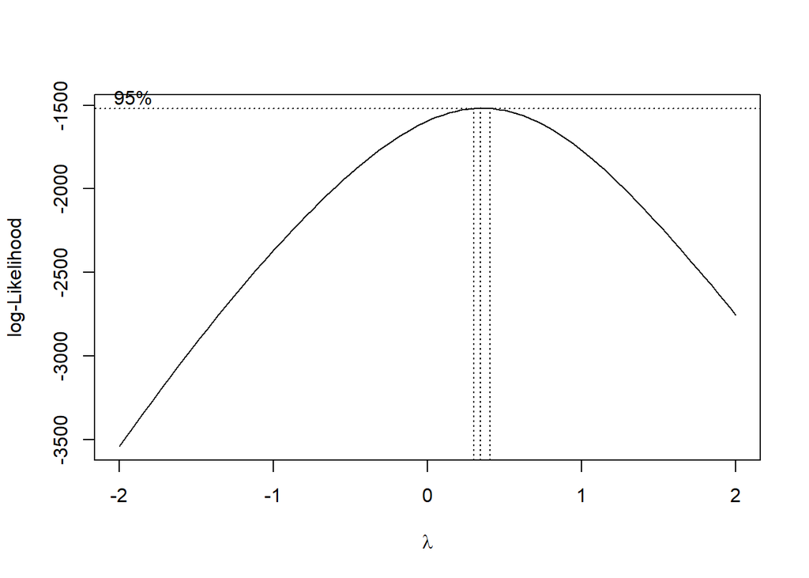

```r
boxcox(Bic_modified_model, plotit = TRUE)
```

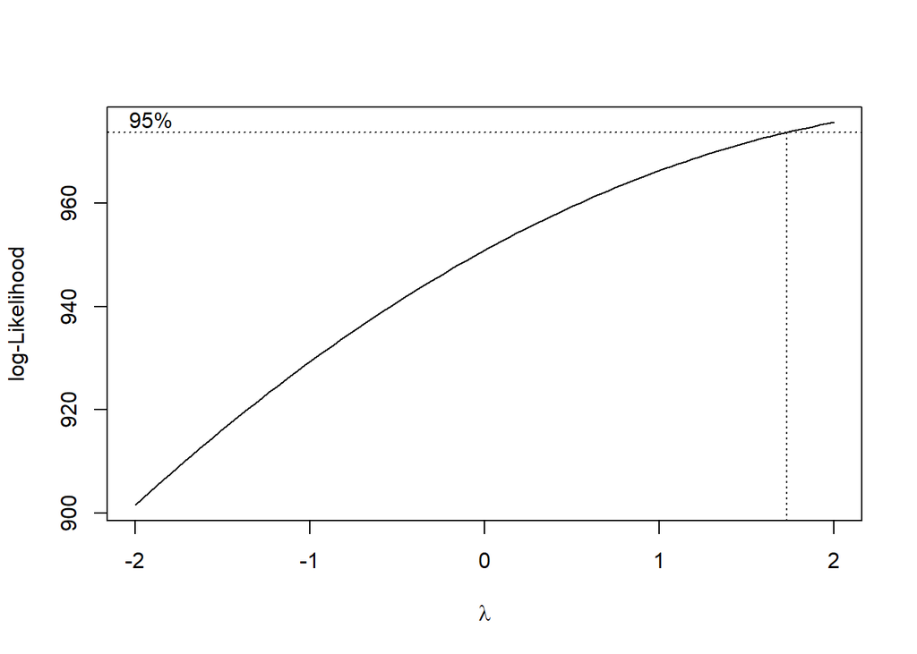

```r
Bic_boxcox_model = lm((((SalePrice ^ 0.5) - 1) / 0.5) ~ LotArea + Neighborhood + BldgType + OverallQual + OverallCond + YearBuilt + MasVnrArea + ExterQual + BsmtQual + BsmtExposure + BsmtFinSF1 +                      BsmtFinSF2 + BsmtUnfSF + X1stFlrSF + X2ndFlrSF + BedroomAbvGr + KitchenQual + Functional + GarageCars + SaleCondition, data = Bic_model_data)


boxcox(bic_backward_response_transformer_model, plotit = TRUE)
```

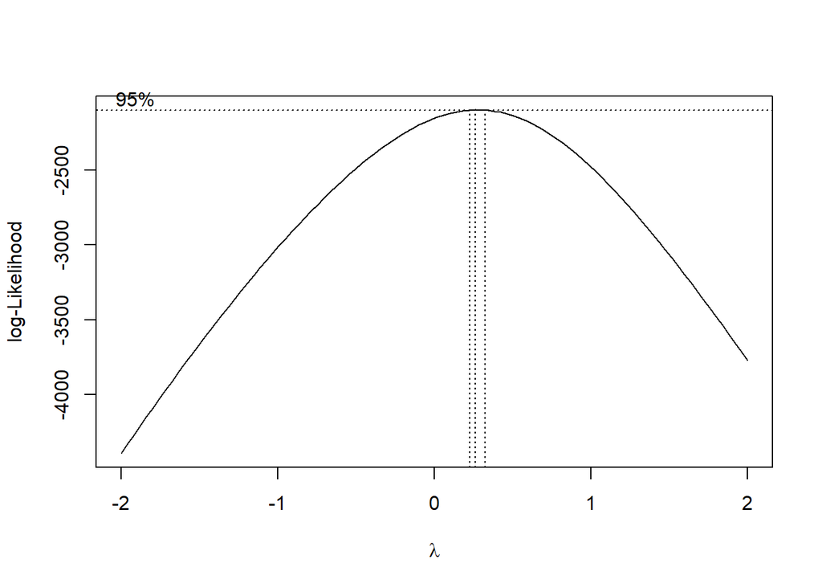

```r
addi_boxcox_model = lm((((SalePrice ^ 0.3) - 1) / 0.3) ~ OverallQual + Neighborhood + TotRmsAbvGrd + GarageArea + BsmtFinSF1 +
                    RoofMatl + OverallCond + X1stFlrSF + X2ndFlrSF + YearBuilt +
                    Condition2 + SaleCondition + BsmtExposure + KitchenAbvGr +  LotArea +
                    KitchenQual + ScreenPorch + Street +  MSSubClass + PoolQC +
                    BsmtFinSF2 + BsmtUnfSF + PoolArea + I(LotArea^2) +  I(YearBuilt^2)+ I(GarageArea^2), house_prices_train)

boxcox(addi_model, plotit = TRUE)
```

```r
poly_boxcox_model = lm(((log(SalePrice)^4.4 - 1) / 4.4) ~ OverallQual + Neighborhood + TotRmsAbvGrd + GarageArea + BsmtFinSF1 +
                    RoofMatl + OverallCond + X1stFlrSF + X2ndFlrSF + YearBuilt +
                    Condition2 + SaleCondition + BsmtExposure + KitchenAbvGr +  LotArea +
                    KitchenQual + ScreenPorch + Street +  MSSubClass + PoolQC +
                    BsmtFinSF2 + BsmtUnfSF + PoolArea + I(LotArea^2) +  I(YearBuilt^2)+ I(GarageArea^2), house_prices_train)
```

> Finally we build more than 10 models,we will check which one is the best one.

```r
model_list = list(list(model = additive_model, main = "Additive Model",
                         shapirotestdata = resid(additive_model)),
                  list(model = additive_modified_model, main = "Additive Modified Model",
                         shapirotestdata = resid(additive_modified_model)),
                  list(model = aic_backward_model, main = "AIC Backward Selected Model",
                         shapirotestdata = resid(aic_backward_model)),
                  list(model = bic_backward_model, main = "BIC Backward Selected Model",
                         shapirotestdata = resid(bic_backward_model)),
                  list(model = bic_backward_response_transformer_model, main = "BIC Response Transformer Model",
                         shapirotestdata = predict(bic_backward_response_transformer_model, newdata = house_prices_train)),
                  list(model = aic_backward_response_transformer_model, main = "AIC Response Transformer Model",
                         shapirotestdata = predict(aic_backward_response_transformer_model, newdata = house_prices_train)),
                  list(model = stepwise_Search_model, main = "Stepwise Search Model",
                         shapirotestdata = predict(stepwise_Search_model, newdata = house_prices_train)),
                  list(model = poly_model, main = "Poly Predictor transformer",
                         shapirotestdata = predict(poly_model, newdata = house_prices_train)),
                  list(model = addi_model, main = "Additive Predictor transformer",
                         shapirotestdata = resid(addi_model)),
                  list(model = Bic_boxcox_model, main = "Bic boxcox Model",
                         shapirotestdata = predict(Bic_boxcox_model, newdata = Bic_model_data)),
                  list(model = addi_boxcox_model, main = "boxcox model",
                         shapirotestdata = predict(addi_boxcox_model, newdata = house_prices_train)),
                  list(model = poly_boxcox_model, main = "Poly boxcox model",
                         shapirotestdata = predict(poly_boxcox_model, newdata = house_prices_train))
                  )
```

> We will do some testing for those models by the following code:

```r
fit_model_test = function(models){
   for(model in models){
      model_plot(model)
   }

   model_diagnostics(models)
}

model_model_diagnostics_table = function(diag_data){
     #kable(diag_data) %>%
     #   kable_styling(full_width = F)

     kable(diag_data) %>%
       kable_styling(bootstrap_options = c("striped", "hover", "condensed", "responsive"))

}

model_plot = function(model){
      #par(mfrow = c(1, 2))
      #fitted_versus_residuals_plot(model)
      #QQ_plot(model)
      par(mfrow = c(2, 2))
      plot(model$model, main = model$main)
}

model_diagnostics = function(models){
   numberofmodel = length(models)
   modelname = rep(" ", numberofmodel)
   shappiro = rep(0, numberofmodel)
   loocvrmse = rep(0, numberofmodel)
   aicvalue = rep(0, numberofmodel)
   bicvalue = rep(0, numberofmodel)
   bptestvalue = rep(0, numberofmodel)
   rsquared = rep(0, numberofmodel)
   adjrsquared = rep(0, numberofmodel)
   i = 1
   for(model in models){
      modelname[i] = model$main
      shappiro[i] = shapiro.test(model$shapirotestdata)$p.value
      loocvrmse[i] = calc_loocv_rmse(model$model)
      aicvalue[i] = extractAIC(model$model)[2]
      bicvalue[i] = extractAIC(model$model, k = log(length(resid(model$model))))[2]
      bptestvalue[i] = bptest(model$model)$p.value
      rsquared[i] = summary(model$model)$r.squared
      adjrsquared[i] = summary(model$model)$adj.r.squared
      i = i + 1
   }

   result = data.frame(model = modelname, shapiro_test = format(shappiro, scientific=T), LOOCV_MSE =loocvrmse,
                          AIC = aicvalue, BIC = bicvalue, adj.r.squared=adjrsquared, bptest = bptestvalue, r.squared=rsquared)
   model_model_diagnostics_table(result)
}
```

# Results

> The following are the models diagnostics result:

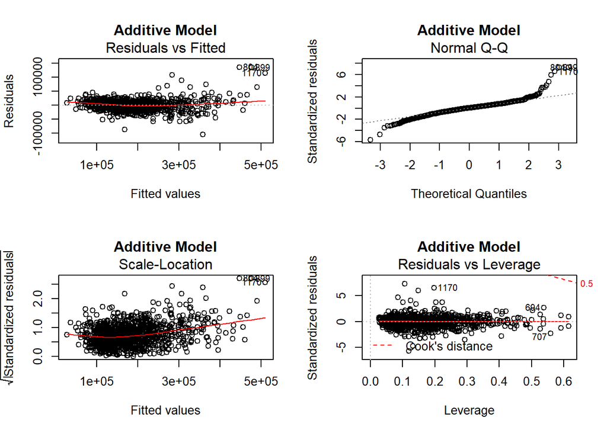

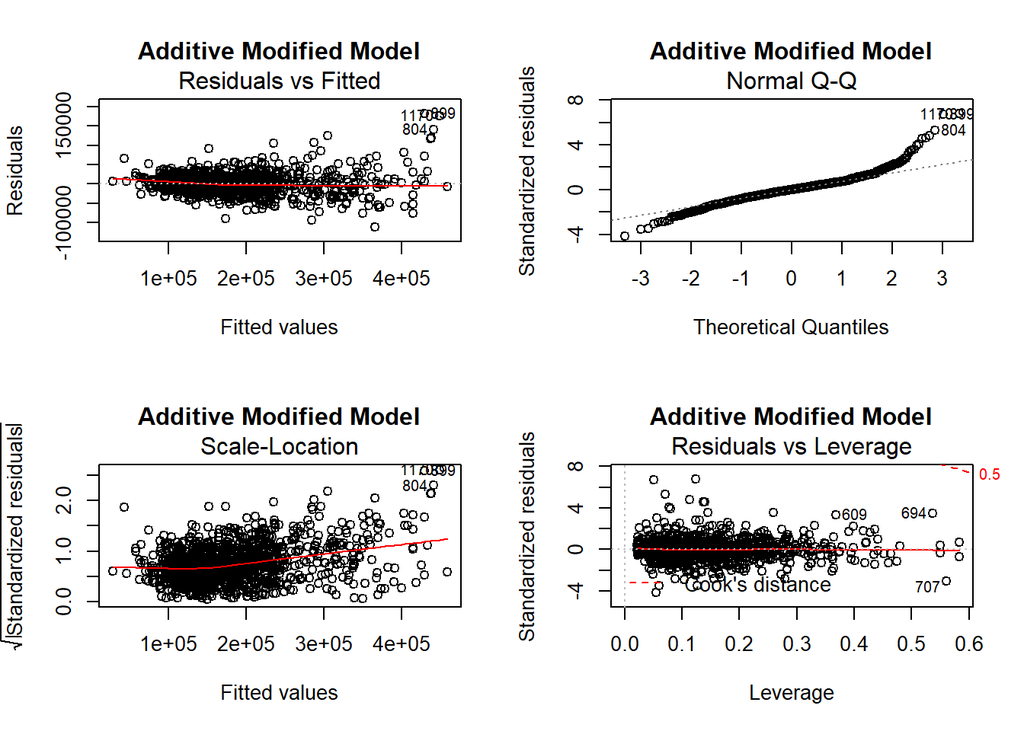

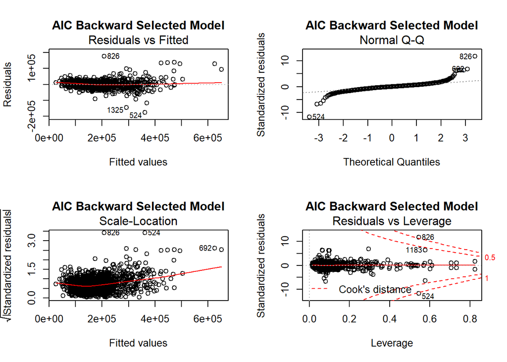

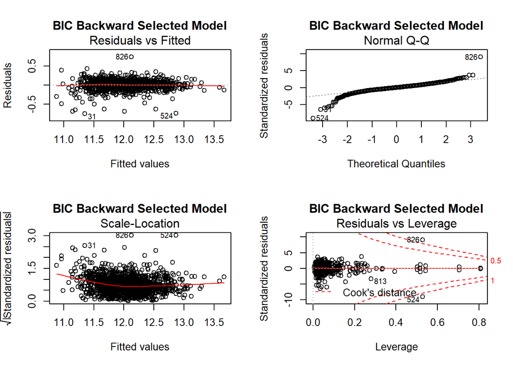

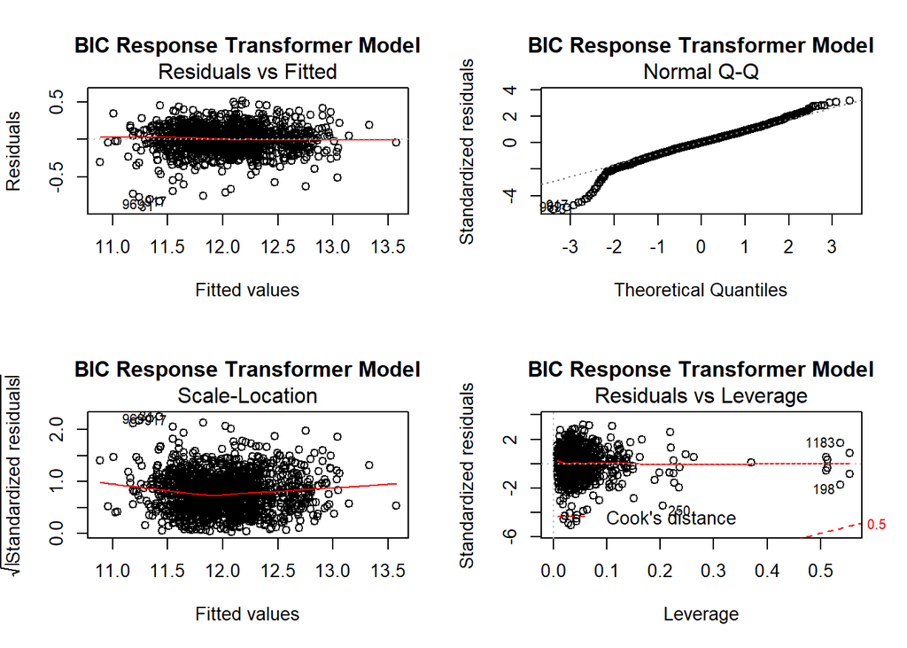

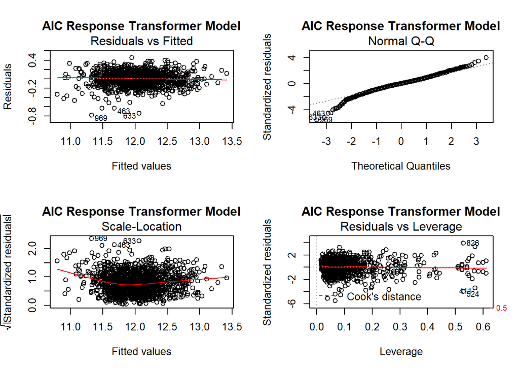

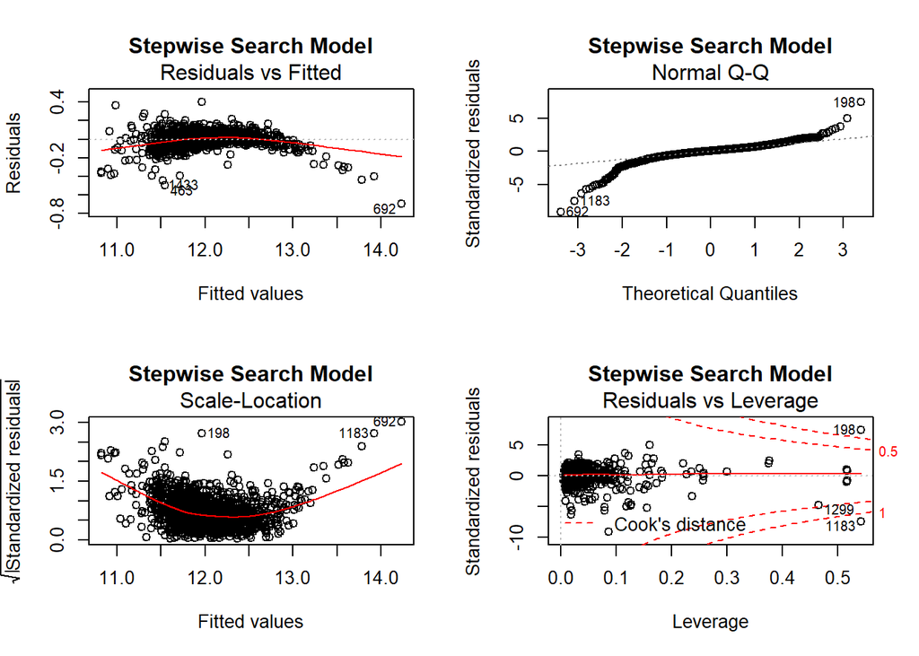

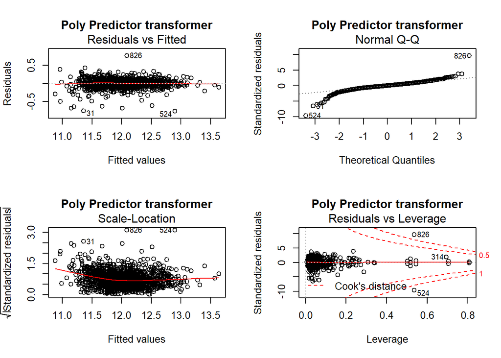

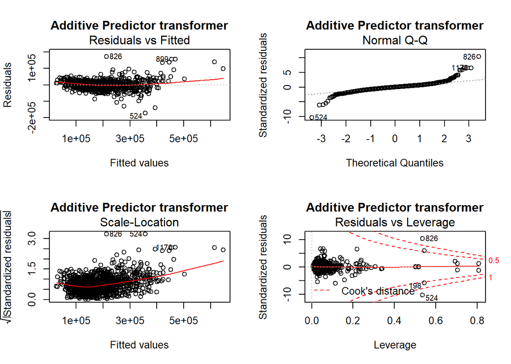

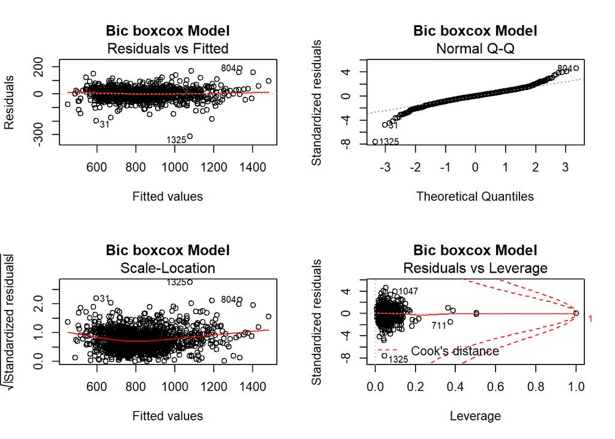

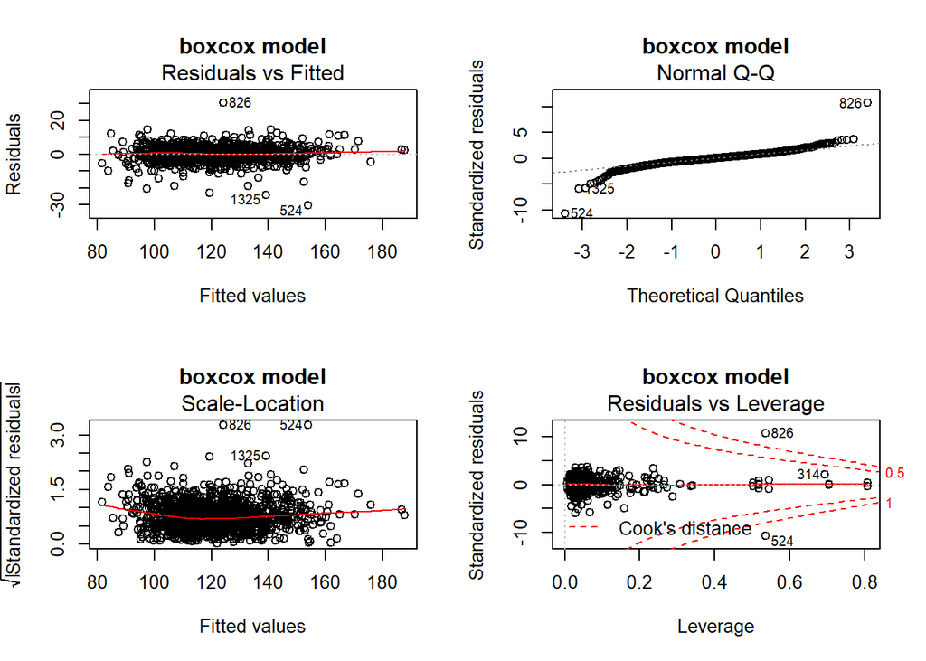

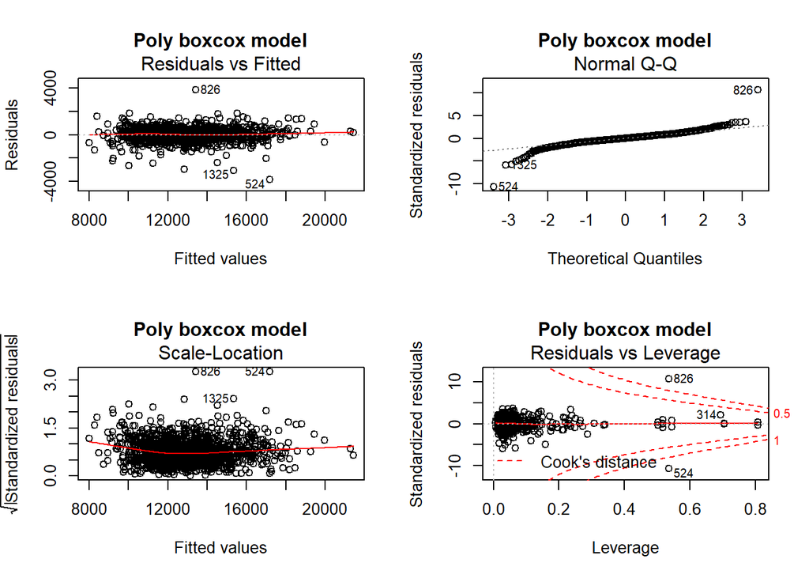

| model | shapiro_test | LOOCV_MSE | AIC | BIC | adj.r.squared | bptest | r.squared |
| --- | --- | --- | --- | --- | --- | --- | --- |
| Additive Model | 1.144850e-26 | Inf | 23392.028 | 24390.458 | 0.9320229 | 0.0000068 | 0.9433814 |
| Additive Modified Model | 3.411731e-23 | Inf | 23665.143 | 24502.887 | 0.8677250 | 0.0000000 | 0.8867367 |
| AIC Backward Selected Model | 1.392466e-34 | Inf | 29401.284 | 30204.785 | 0.9200212 | 0.0000000 | 0.9282987 |
| BIC Backward Selected Model | 1.095663e-27 | Inf | -6168.432 | -5798.398 | 0.9125237 | 0.0000000 | 0.9166607 |
| BIC Response Transformer Model | 4.186996e-07 | Inf | -5180.344 | -4836.742 | 0.8273271 | 0.0000000 | 0.8349015 |
| AIC Response Transformer Model | 1.478221e-06 | Inf | -5466.770 | -4668.555 | 0.8655705 | 0.0001198 | 0.8793912 |
| Stepwise Search Model | 3.616705e-16 | Inf | -7331.328 | -7098.735 | 0.9598771 | 0.0000000 | 0.9610596 |
| Poly Predictor transformer | 3.174684e-07 | Inf | -6184.014 | -5798.122 | 0.9136208 | 0.0000000 | 0.9178836 |
| Additive Predictor transformer | 1.199392e-31 | Inf | 29577.261 | 29963.153 | 0.9051906 | 0.0000000 | 0.9098693 |
| Bic boxcox Model | 2.196948e-16 | 43.74825 | 9165.676 | 9471.876 | 0.9352432 | 0.0000000 | 0.9383878 |
| boxcox model | 7.829847e-14 | Inf | 4237.856 | 4623.747 | 0.9232705 | 0.0000000 | 0.9270570 |
| Poly boxcox model | 1.984848e-13 | Inf | 18382.983 | 18768.875 | 0.9232218 | 0.0000000 | 0.9270107 |

```r
fit_model_test(model_list)
```

```r
final_model = Bic_boxcox_model
final_model_train_data = Bic_model_data
```

# Discussion

> The next, We will do the prediction by using the test data to see how good is the final model.

```r
test_vs_train_plot = function(model, train, test, predict_result){
   trn_df = data.frame(house_price = fitted(model), year_built = train[, "YearBuilt"] )
   test_df = data.frame(house_price = predict_result, year_built= test[ , "YearBuilt"])

   ggplot(data = trn_df, aes(x = year_built, y = house_price, colour = 'Train')) +
      geom_line() +
      geom_line(data = test_df, aes(x=year_built, y=house_price, colour = 'Test'), show.legend = FALSE) +
      labs(x = "Year Build", y = "House Price", title = "Train vs Test prediction Plot") +
      theme(plot.title = element_text(hjust = 0.5)) +
      scale_color_discrete(name = "Legend", labels = c("Train", "Test")) +
      scale_color_manual(values=c("red", "blue"))

}
```

```r
test_data = read.csv("test.csv", stringsAsFactors = FALSE)[, -1]
house_prices_test_data = preprocess(test_data)
house_prices_test_data = remove_unusual_observations(final_model, house_prices_test_data)
house_prices_test_data = remove_no_existing_factors(house_prices_test_data, final_model_train_data)
house_prices_test_data = drop_only_one_level_factor(house_prices_test_data)
predict_house_price =  predict(final_model, newdata = house_prices_test_data, na.action = "na.exclude")
```

[output not shown]

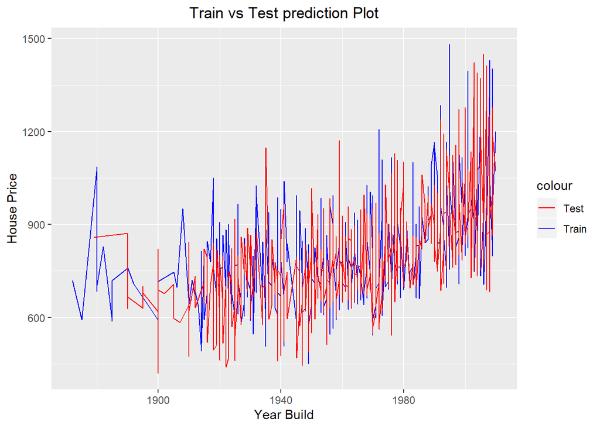

```r
test_vs_train_plot(final_model, final_model_train_data, house_prices_test_data, predict_house_price)
```

# Appendix

> We will try an automatic method to generate the Box-Cox parameter, and then we will use build a new BOX-Cox model with the final model by using this new parameter.

```r
boxcoxbycaret = BoxCoxTrans(Bic_model_data$SalePrice)
summary(boxcoxbycaret)
```

```
##          Length Class          Mode
## lambda   1      -none-         numeric
## fudge    1      -none-         numeric
## n        1      -none-         numeric
## summary  6      summaryDefault numeric
## ratio    1      -none-         numeric
## skewness 1      -none-         numeric
```

```r
boxcoxbycaret_model = lm((SalePrice - 1) ~ LotArea + Neighborhood + BldgType + OverallQual + OverallCond + YearBuilt +
    MasVnrArea + ExterQual + BsmtQual + BsmtExposure + BsmtFinSF1 + BsmtFinSF2 + BsmtUnfSF + X1stFlrSF + X2ndFlrSF +
    BedroomAbvGr + KitchenQual + Functional + GarageCars + SaleCondition, data = Bic_model_data)

model_list = list(list(model = final_model, main = "Final Model",
                         shapirotestdata = predict(final_model, newdata = Bic_model_data)),
                  list(model = boxcoxbycaret_model, main = "Box-Cox by Caret Model",
                         shapirotestdata = predict(boxcoxbycaret_model, newdata = Bic_model_data)) )
model_diagnostics(model_list)
```

| model | shapiro_test | LOOCV_MSE | AIC | BIC | adj.r.squared | bptest | r.squared |
| --- | --- | --- | --- | --- | --- | --- | --- |
| Final Model | 2.196948e-16 | 43.74825 | 9165.676 | 9471.876 | 0.9352432 | 0 | 0.9383878 |
| Box-Cox by Caret Model | 9.143645e-24 | 21799.94694 | 24265.166 | 24571.365 | 0.9232397 | 0 | 0.9269672 |

> The Final Model is still better than the new model.